# Dungeness crab Bioenergetic - run OA diets

Kirstin Holsman, Mary Fisher

# Description

Compare growth rates of crab with OA diets.

To Do List:

- check weight calculation in sim_W function – weight is too high!

```
## ------------------------------
## NRG/setup.R settings
## ------------------------------
## ------------------------------
## ------------------------------
```

# 1. Getting set up

## 1.1. Parameters

```r
parms <- crabPARMS_USE %>% filter(X=="Cmagister"); str(parms)
```

```
## 'data.frame':    1 obs. of  30 variables:
##  $ X    : Factor w/ 3 levels "Cgracilis","Cmaenas",..: 3
##  $ RFR  : int 1
##  $ Qox  : num 13560
##  $ a    : logi NA
##  $ Ceq  : int 3
##  $ Req  : int 0
##  $ Weq  : int 1
##  $ Tco  : num 14.5
##  $ Tcm  : num 20.2
##  $ QC   : int 5
##  $ Tcl  : num 21.2
##  $ CK1  : num 0.42
##  $ CK4  : num 0.83
##  $ CA   : num 6.6
```

[output cut: 16 more lines]

Note that:

- Ceq is opt 3,
- Req is opt 0 – user-specified respiration model.

## 1.2. Data object

The Dungeness crab data object is saved into NRG. Note that the units in this data / additional parameters all match the units in the parameters object. The respiration function, exuvia energy loss, and proportion I loss are from McDonald et al. (2006). Let’s set prey energy density is to be equivalent to predator energy density, representing a 100% cannibalistic diet (!).

```r
str(dcrab_data)
```

```
## List of 18
##  $ W           : num 4
##  $ TempC       : num [1:251] 0 0.1 0.2 0.3 0.4 0.5 0.6 0.7 0.8 0.9 ...
##  $ Eprey       : num 13420
##  $ propDiet    : num 1
##  $ Epred       : num 19380
##  $ propL       : num 0
##  $ Espawn      : num 0
##  $ spawn       : num 0
##  $ propIloss   : num 0
##  $ propS       : num 0
##  $ Exuvia      :List of 4
##   ..$ ED_Jg: logi NA
##   ..$ a    : num 0.000164
##   ..$ b    : num 2.79
##   ..$ CW_mm: logi NA
##  $ molt        : num 0
##  $ propIndigest: num 0
##  $ diet        : num 0
##  $ RC          : num -0.152
##  $ RD          : num 6.21
##  $ customresp  :function (par, data)
##  $ crab        : num 1
```

```r
dcrab_data$Eprey <- dcrab_data$Epred
```

Molting information is also provided as a data frame.

```r
str(dataMOLT$Cmagister)
```

```
## List of 5
##  $ mod    : num 1
##  $ ip     :'data.frame': 1 obs. of  2 variables:
##   ..$ a: num 5.25
##   ..$ b: num 0.0175
##  $ mi     :'data.frame': 1 obs. of  3 variables:
##   ..$ a: num 1.3
##   ..$ b: num 0.23
##   ..$ c: num 0.22
##  $ exuviaW: num 0.03
##  $ DD     :'data.frame': 1 obs. of  2 variables:
##   ..$ Tmin       : num 5
##   ..$ DDthreshold: logi NA
```

Energy lost to exuvia is modeled as a proportion of body mass. The molt model is set to `1`, which means that molting increment will be based on carapace width (as opposed to degree-days)

### 1.3. Temperature

For now, use temperature loggers from the intertidal in Willapa Bay, WA. Provided by WSG Crab Team

```r
load(here(nrg_dir,'data','WillapaBayTemperature.rds'))
```

Get a daily average temperature

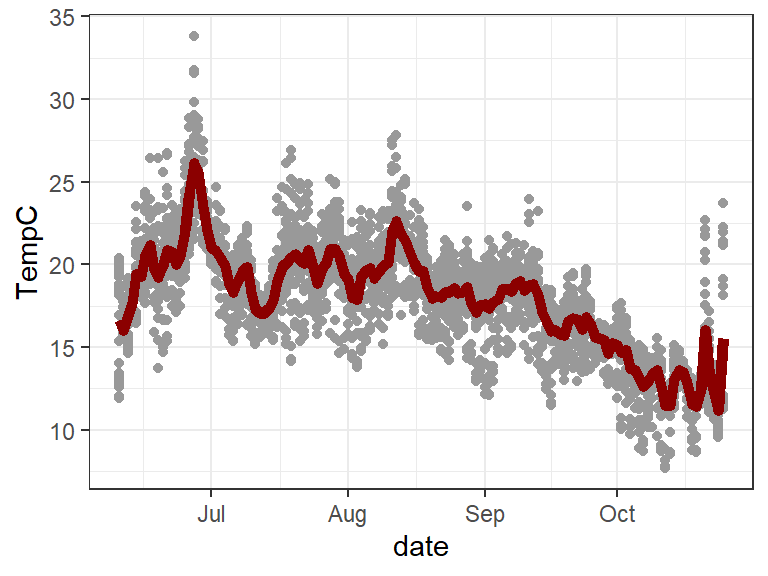

```r
Tdat_raw <- WillapaBayTemperature$WB.oysterville.2021

Tdat <- Tdat_raw %>%
  group_by(date) %>%
  summarise(TempC=mean(TempC))
ggplot() + geom_point(data=Tdat_raw, aes(x=date, y=TempC), col="grey60") +
  geom_path(data=Tdat, aes(x=date,y=TempC, group=1), col="darkred", linewidth=2)
```

Then subset the temperature data to run between Jul 1 and October 1.

```r
summerTdat <- Tdat %>% filter(ymd(date) < ymd('2021-10-01') & ymd(date) > ymd('2021-07-01'))
```

### 1.4. Test sim_W

Make sure that NRG will work with data given, by running sim_w.

#### tiny crab

This crab is small, so it should molt frequently

Set up the simulation with some fake weights

```r
nd     <-  dim(summerTdat)[1] # days of simulation
# at start of simulation
Wstart <- 0.1

## made up simulation day, weights + date
Wobs   <- data.frame(
  day = c(1,nd),
  W   = c(Wstart,0.8))
Wobs$date <- summerTdat$date[Wobs$day]

# simulation data
sim_dat       <- dcrab_data
sim_dat$TempC <- summerTdat$TempC     ## temperatures
sim_dat$W     <- Wstart         ## set W data for the simulation to the first observed weight

DCRBdat4sim   <- list(
                  Wtarget  = Wobs,
                  parSIM  = parms,
                  simTdat = summerTdat,
                  dataSIM  = sim_dat,
                  dataMOLT = dataMOLT$Cmagister)

sim_out       <- summerTdat %>% mutate(W=0)
```

```r
dcrb.oy.sim <- sim_W(par=0.4, dataIN=DCRBdat4sim, LL=F)
```

```
## WARNING: crab weight is less than 8% of carapace width on day 2. (2.152%)
```

```
## WARNING: crab weight is less than 8% of carapace width on day 3. (3.851%)
```

```
## WARNING: crab weight is less than 8% of carapace width on day 4. (6.683%)
```

```
## daily growth includes energy lost to exuvia / spawning (3235.99 J/g predator)
```

```
## carapace width 195.44 calculated from weight; using the equation: 0.000164 * CW^2.79.
```

```
## daily growth includes energy lost to exuvia / spawning (3235.99 J/g predator)
```

```
## carapace width 474.61 calculated from weight; using the equation: 0.000164 * CW^2.79.
```

```
## daily growth includes energy lost to exuvia / spawning (3235.99 J/g predator)
```

```
## carapace width 880.84 calculated from weight; using the equation: 0.000164 * CW^2.79.
```

```
## daily growth includes energy lost to exuvia / spawning (3235.99 J/g predator)
```

```
## carapace width 1340.75 calculated from weight; using the equation: 0.000164 * CW^2.79.
```

```
## Your crab molted on day: 21, 43, 67, 91,
```

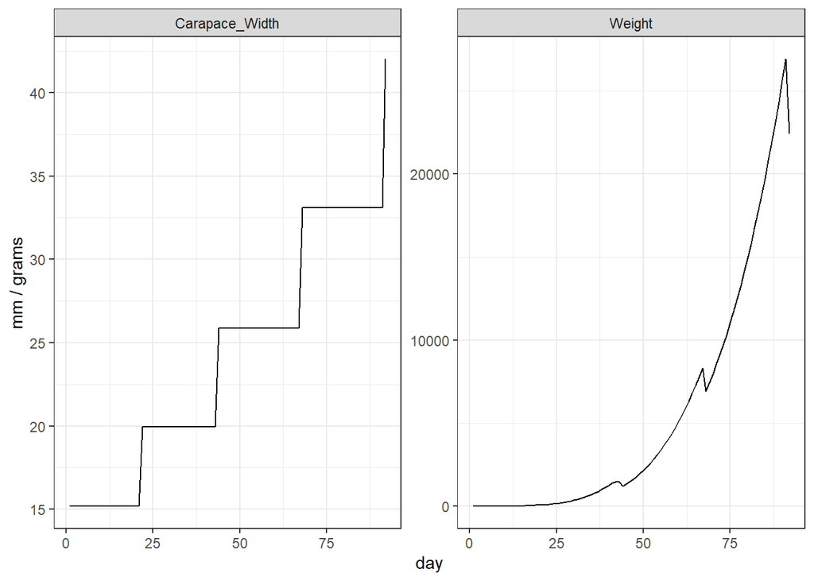

#### mid-sized crab

This crab is a little larger, so it should molt less frequently

Set up the simulation with some fake weights

```r
nd     <-  dim(summerTdat)[1] # days of simulation
# at start of simulation
Wstart <- 0.8

## made up simulation day, weights + date
Wobs   <- data.frame(
  day = c(1,nd),
  W   = c(Wstart,1.2))
Wobs$date <- summerTdat$date[Wobs$day]

# simulation data
sim_dat       <- dcrab_data
sim_dat$TempC <- summerTdat$TempC     ## temperatures
sim_dat$W     <- Wstart         ## set W data for the simulation to the first observed weight

DCRBdat4sim   <- list(
                  Wtarget  = Wobs,
                  parSIM  = parms,
                  simTdat = summerTdat,
                  dataSIM  = sim_dat,
                  dataMOLT = dataMOLT$Cmagister)

sim_out       <- summerTdat %>% mutate(W=0)
```

```r
dcrb.oy.sim <- sim_W(par=0.4, dataIN=DCRBdat4sim, LL=F)
```

```
## WARNING: crab weight is less than 8% of carapace width on day 2. (6.187%)
```

```
## daily growth includes energy lost to exuvia / spawning (3235.99 J/g predator)
```

```
## carapace width 341.1 calculated from weight; using the equation: 0.000164 * CW^2.79.
```

```
## daily growth includes energy lost to exuvia / spawning (3235.99 J/g predator)
```

```
## carapace width 824.37 calculated from weight; using the equation: 0.000164 * CW^2.79.
```

```
## daily growth includes energy lost to exuvia / spawning (3235.99 J/g predator)
```

```
## carapace width 1473.55 calculated from weight; using the equation: 0.000164 * CW^2.79.
```

```
## Your crab molted on day: 28, 59, 91,
```

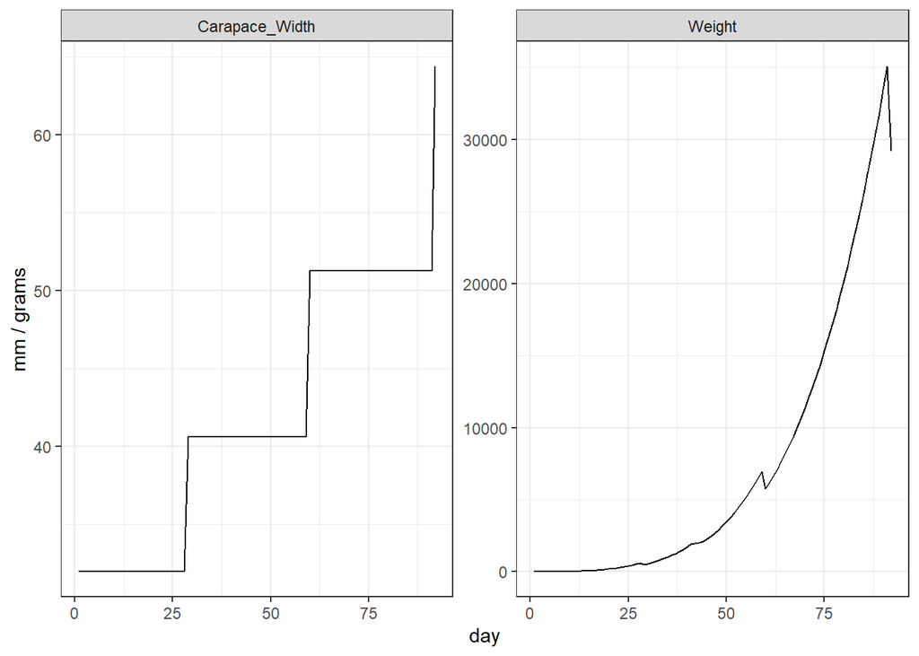

### 1.5 Crab sizes

What is the smallest sized crab that I collected? Convert this to mass (g AFDW) using the conversion equation in NRG. (*Note* - the smallest size I recorded falls within the “late cohor” J1 instar size range, which is usually present in the Puget Sound intertidal in early July)

```r
lab_metadat <- read_csv(here('../../','data','metadata','crab_metadat.csv'))
min(lab_metadat$CW_mm)
```

```
## [1] 5
```

```r
W_start <- cw2afdw(CW=5); W_start
```

```
## [1] 0.004518174
```

By late September, crab in the Puget Sound are generally at the J7 stage; ~40mm carapace width is the largest size for the “late cohort” range, and the smallest size for the “early cohort” range. Convert this to mass (g AFDW) using the conversion equation in NRG.

```r
W_end <- cw2afdw(CW=40); W_end
```

```
## [1] 1.494803
```

# 2. Prep Diet Profiles

Read in all of the prey items identified as having particularly high / low OA impacts, and their energy densities. The “High Exposure” diet will consist only of prey items with lower / positive OA impact, whereas the “Low Exposure” diet will pull from the full suite of prey taxa.

```r
oadiets <- read_csv(here('../../','data','bioE','OAdiets_HiLo_Condensed_EnergyDensities.csv'))
oadiets %<>%
  bind_rows(oadiets %>% filter(OA.diet.group=="high") %>% mutate(OA.diet.group="low"))
```

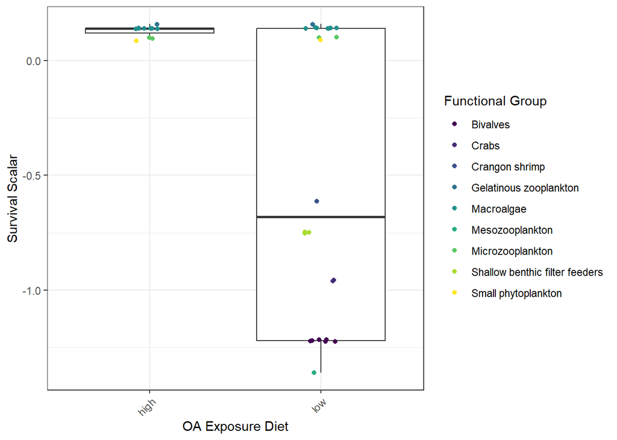

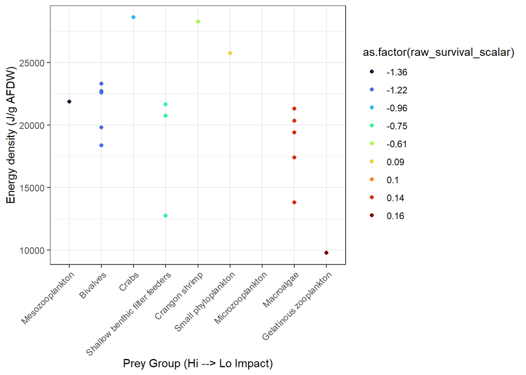

```r
oadiets %>% ggplot(aes(x=OA.diet.group,y=raw_survival_scalar)) +
  geom_boxplot()+
  geom_jitter(aes(color=functional_group), width=0.1) +
  scale_color_viridis_d(option="rainbow", name="Functional Group") +
  labs(x="OA Exposure Diet",y="Survival Scalar") +
  theme(axis.text.x=element_text(angle=45,hjust=1))
```

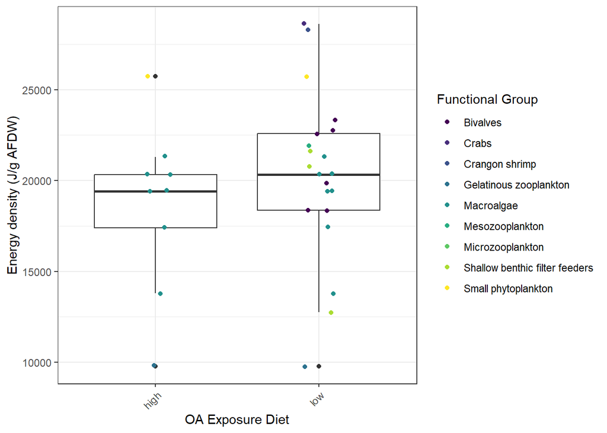

```r
png(here('../../','figs','figS_bioE_OAdiets_EDvGroup.png'))
pdiet1
dev.off()
```

```r
png(here('../../','figs','figS_bioE_OAdiets_EDvExposureGroup.png'), res=300,height=1200,width=1500)
pdiet2
dev.off()
```

```r
oadiets.grouped <- oadiets %>% filter(OA.diet.group=="high") %>%
       mutate(med.ED=median(ed_JgAFDW,na.rm=TRUE)) %>%
       mutate(ED.group=ifelse(ed_JgAFDW > med.ED,"high","low")) %>% dplyr::select(-med.ED) %>%
  bind_rows(
    bind_rows(oadiets %>% filter(OA.diet.group=="low") %>%
              slice_max(order_by=ed_JgAFDW, n=5) %>% mutate(ED.group="high"),
              oadiets %>% filter(OA.diet.group=="low") %>%
              slice_min(order_by=ed_JgAFDW, n=5) %>% mutate(ED.group="low")))
oadiets.grouped %>% group_by(OA.diet.group,ED.group) %>% summarise(n())
```

| OA.diet.group | ED.group | n() |
| --- | --- | --- |
| high | high | 4 |
| high | low | 5 |
| high | NA | 2 |
| low | high | 5 |
| low | low | 6 |

**reset RFR to 1.0**

```r
parms$RFR <- 1
```

# 3a. Simulate Growth: 1 prey item

Start by simulating a diet composed of only 1 prey item (the highest / lowest ED prey)

```r
diets.df1 <- oadiets.grouped %>%
  ## highest ED prey for each group
  group_by(OA.diet.group) %>%
  slice_max(order_by=ed_JgAFDW,n=1) %>%
  ## lowest ED prey for each group
  bind_rows(oadiets.grouped %>%
              group_by(OA.diet.group) %>%
              slice_max(order_by=(-ed_JgAFDW),n=1))
```

### low OA exposure

The prey item with the highest / lowest ED, of all taxa

```r
tmp_diet <- diets.df1 %>% filter(OA.diet.group=="low") %>%
  dplyr::select(new_taxon2,ED.group,ed_JgAFDW)
tmp_diet
```

| OA.diet.group | new_taxon2 | ED.group | ed_JgAFDW |
| --- | --- | --- | --- |
| low | Hemigrapsus oregonensis | high | 28605 |
| low | Phacellophora camtschatica | low | 9785 |

Set up the simulation: **high energy density**

```r
filter(tmp_diet, ED.group=="high")$ed_JgAFDW
```

```
## [1] 28605
```

```r
sim_dat <- dcrab_data

## adjust diet information
sim_dat$Eprey <- filter(tmp_diet, ED.group=="high")$ed_JgAFDW
sim_dat$propDiet <- 1

## temperatures
sim_dat$TempC <- summerTdat$TempC     ## temperatures

## starting crab weight
sim_dat$W     <- W_start         ## set W data for the simulation to the first observed weight


##
nd     <-  dim(summerTdat)[1] # days of simulation

## weights at start and end of simulation
Wobs   <- data.frame(
  day = c(1,nd),
  W   = c(W_start,W_end))
Wobs$date <- summerTdat$date[Wobs$day]

# simulation data frames
DCRBdat4sim   <- list(
                  Wtarget  = Wobs,
                  parSIM  = parms,
                  simTdat = summerTdat,
                  dataSIM  = sim_dat,
                  dataMOLT = dataMOLT$Cmagister)

sim_out       <- summerTdat %>% mutate(W=0)
```

simulate!

```r
oa1.lowOhiE.sim <- sim_W(par=parms$RFR, dataIN=DCRBdat4sim, LL=F)
```

```
## WARNING: crab weight is less than 8% of carapace width on day 2. (4.564%)
```

```
## daily growth includes energy lost to exuvia / spawning (3235.99 J/g predator)
```

```
## carapace width 671.73 calculated from weight; using the equation: 0.000164 * CW^2.79.
```

```
## daily growth includes energy lost to exuvia / spawning (3235.99 J/g predator)
```

```
## carapace width 1996.92 calculated from weight; using the equation: 0.000164 * CW^2.79.
```

```
## daily growth includes energy lost to exuvia / spawning (3235.99 J/g predator)
```

```
## carapace width 3422.24 calculated from weight; using the equation: 0.000164 * CW^2.79.
```

```
## daily growth includes energy lost to exuvia / spawning (3235.99 J/g predator)
```

```
## carapace width 5546.94 calculated from weight; using the equation: 0.000164 * CW^2.79.
```

```
## daily growth includes energy lost to exuvia / spawning (3235.99 J/g predator)
```

```
## carapace width 7391.49 calculated from weight; using the equation: 0.000164 * CW^2.79.
```

```
## Your crab molted on day: 18, 36, 54, 74, 91,
```

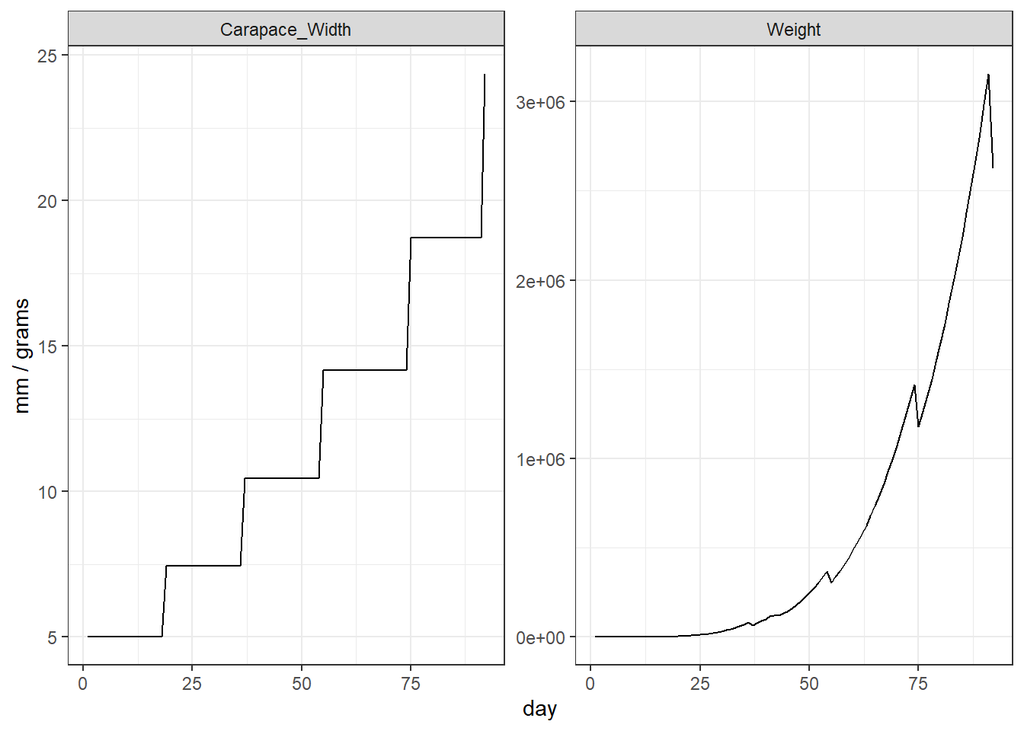

```r
plot.sim(sim.out =oa1.lowOhiE.sim,nd=nd)
```

The carapace widths look normal, but that weight is out of control! final weight:

```r
oa1.lowOhiE.sim$W[nd]
```

```
## [1] 3152094
```

Set up the simulation: **low energy density**

```r
filter(tmp_diet, ED.group=="low")$ed_JgAFDW
```

```
## [1] 9785
```

```r
sim_dat <- dcrab_data

## adjust diet information
sim_dat$Eprey <- filter(tmp_diet, ED.group=="low")$ed_JgAFDW
sim_dat$propDiet <- 1

## temperatures
sim_dat$TempC <- summerTdat$TempC     ## temperatures

## starting crab weight
sim_dat$W     <- W_start         ## set W data for the simulation to the first observed weight


##
nd     <-  dim(summerTdat)[1] # days of simulation

## weights at start and end of simulation
Wobs   <- data.frame(
  day = c(1,nd),
  W   = c(W_start,W_end))
Wobs$date <- summerTdat$date[Wobs$day]

# simulation data frames
DCRBdat4sim   <- list(
                  Wtarget  = Wobs,
                  parSIM  = parms,
                  simTdat = summerTdat,
                  dataSIM  = sim_dat,
                  dataMOLT = dataMOLT$Cmagister)

sim_out       <- summerTdat %>% mutate(W=0)
```

simulate!

```r
oa1.lowOlowE.sim <- sim_W(par=parms$RFR, dataIN=DCRBdat4sim, LL=F)
```

```
## WARNING: crab weight is less than 8% of carapace width on day 2. (0.409%)
```

```
## WARNING: crab weight is less than 8% of carapace width on day 3. (1.107%)
```

```
## WARNING: crab weight is less than 8% of carapace width on day 4. (2.887%)
```

```
## WARNING: crab weight is less than 8% of carapace width on day 5. (6.72%)
```

```
## daily growth includes energy lost to exuvia / spawning (3235.99 J/g predator)
```

```
## carapace width 157.52 calculated from weight; using the equation: 0.000164 * CW^2.79.
```

```
## daily growth includes energy lost to exuvia / spawning (3235.99 J/g predator)
```

```
## carapace width 450.74 calculated from weight; using the equation: 0.000164 * CW^2.79.
```

```
## daily growth includes energy lost to exuvia / spawning (3235.99 J/g predator)
```

```
## carapace width 766.05 calculated from weight; using the equation: 0.000164 * CW^2.79.
```

```
## daily growth includes energy lost to exuvia / spawning (3235.99 J/g predator)
```

```
## carapace width 1237.62 calculated from weight; using the equation: 0.000164 * CW^2.79.
```

```
## daily growth includes energy lost to exuvia / spawning (3235.99 J/g predator)
```

```
## carapace width 1647.03 calculated from weight; using the equation: 0.000164 * CW^2.79.
```

```
## Your crab molted on day: 18, 36, 54, 74, 91,
```

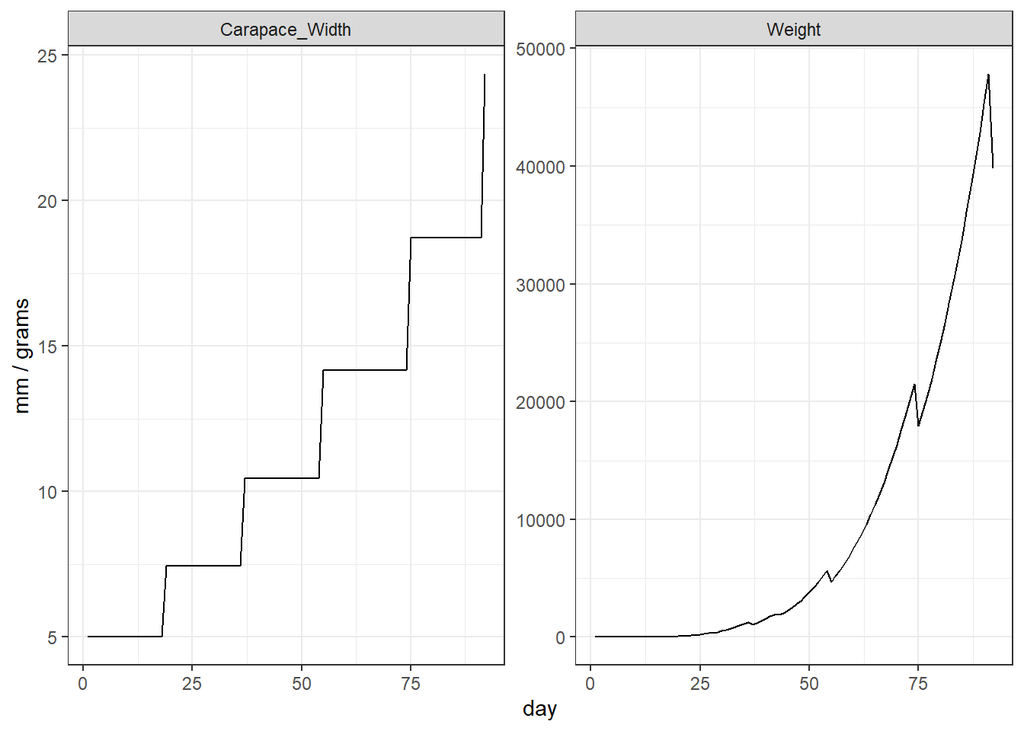

```r
plot.sim(sim.out =oa1.lowOlowE.sim,nd=nd)
```

final weight:

```r
oa1.lowOlowE.sim$W[nd]
```

```
## [1] 47800.93
```

How does the “high OA exposure” diet this compare to the “low OA exposure” diet in terms of…

Growth each day

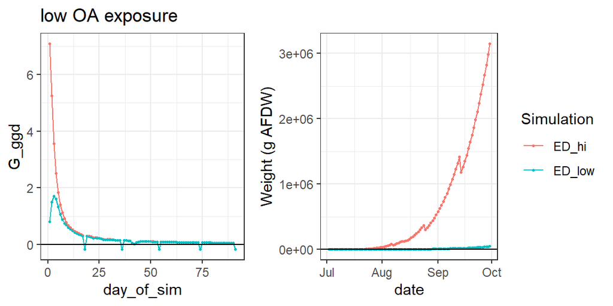

```r
p1 <- data.frame(TempC=summerTdat$TempC,
                        date=summerTdat$date,
                        day_of_sim=seq(1,nd),
                        ED_hi=oa1.lowOhiE.sim$G_ggd[1:nd],
                        ED_low=oa1.lowOlowE.sim$G_ggd[1:nd]) %>%
  pivot_longer(cols=c(4:5),names_to="Simulation", values_to="G_ggd") %>%
ggplot( aes(x=day_of_sim,y=G_ggd,col=Simulation)) +
  geom_point(size=0.5) +
  geom_path() +
  geom_hline(aes(yintercept=0)) +
  labs(title="low OA exposure") + theme(legend.position = "none")
p2 <- data.frame(TempC=summerTdat$TempC,
                        date=summerTdat$date,
                        day_of_sim=seq(1,nd),
                        ED_hi=oa1.lowOhiE.sim$W[1:nd],
                        ED_low=oa1.lowOlowE.sim$W[1:nd]) %>%
  pivot_longer(cols=c(4:5),names_to="Simulation", values_to="Weight (g AFDW)") %>%
ggplot( aes(x=date,y=`Weight (g AFDW)`,col=Simulation)) +
  geom_point(size=0.5) +
  geom_path() +
  geom_hline(aes(yintercept=0)) +
  labs(title="")
plot_grid(p1,p2,ncol=2, rel_widths=c(0.7,1))
```

### high OA exposure

The prey item with the highest / lowest ED, of all taxa

```r
tmp_diet <- diets.df1 %>% filter(OA.diet.group=="high") %>%
  dplyr::select(new_taxon2,ED.group,ed_JgAFDW)
tmp_diet
```

| OA.diet.group | new_taxon2 | ED.group | ed_JgAFDW |
| --- | --- | --- | --- |
| high | Single-celled phytoplankton | high | 25735 |
| high | Phacellophora camtschatica | low | 9785 |

Set up the simulation: **high energy density**

```r
filter(tmp_diet, ED.group=="high")$ed_JgAFDW
```

```
## [1] 25735
```

```r
sim_dat <- dcrab_data

## adjust diet information
sim_dat$Eprey <- filter(tmp_diet, ED.group=="high")$ed_JgAFDW
sim_dat$propDiet <- 1

## temperatures
sim_dat$TempC <- summerTdat$TempC     ## temperatures

## starting crab weight
sim_dat$W     <- W_start         ## set W data for the simulation to the first observed weight


##
nd     <-  dim(summerTdat)[1] # days of simulation

## weights at start and end of simulation
Wobs   <- data.frame(
  day = c(1,nd),
  W   = c(W_start,W_end))
Wobs$date <- summerTdat$date[Wobs$day]

# simulation data frames
DCRBdat4sim   <- list(
                  Wtarget  = Wobs,
                  parSIM  = parms,
                  simTdat = summerTdat,
                  dataSIM  = sim_dat,
                  dataMOLT = dataMOLT$Cmagister)

sim_out       <- summerTdat %>% mutate(W=0)
```

simulate!

```r
oa1.hiOhiE.sim <- sim_W(par=parms$RFR, dataIN=DCRBdat4sim, LL=F)
```

```
## WARNING: crab weight is less than 8% of carapace width on day 2. (3.728%)
```

```
## daily growth includes energy lost to exuvia / spawning (3235.99 J/g predator)
```

```
## carapace width 585.28 calculated from weight; using the equation: 0.000164 * CW^2.79.
```

```
## daily growth includes energy lost to exuvia / spawning (3235.99 J/g predator)
```

```
## carapace width 1729.92 calculated from weight; using the equation: 0.000164 * CW^2.79.
```

```
## daily growth includes energy lost to exuvia / spawning (3235.99 J/g predator)
```

```
## carapace width 2959.86 calculated from weight; using the equation: 0.000164 * CW^2.79.
```

```
## daily growth includes energy lost to exuvia / spawning (3235.99 J/g predator)
```

```
## carapace width 4792.9 calculated from weight; using the equation: 0.000164 * CW^2.79.
```

```
## daily growth includes energy lost to exuvia / spawning (3235.99 J/g predator)
```

```
## carapace width 6383.84 calculated from weight; using the equation: 0.000164 * CW^2.79.
```

```
## Your crab molted on day: 18, 36, 54, 74, 91,
```

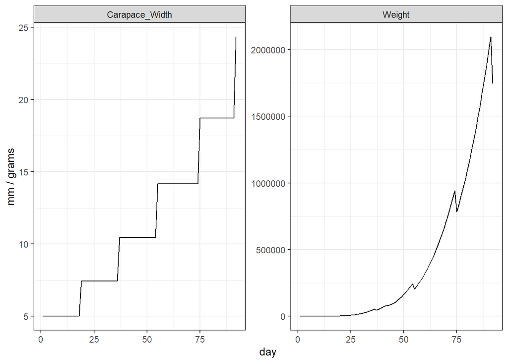

```r
plot.sim(sim.out =oa1.hiOhiE.sim,nd=nd)
```

final weight:

```r
oa1.hiOhiE.sim$W[nd]
```

```
## [1] 2094185
```

Set up the simulation: **low energy density**

```r
filter(tmp_diet, ED.group=="low")$ed_JgAFDW
```

```
## [1] 9785
```

```r
sim_dat <- dcrab_data

## adjust diet information
sim_dat$Eprey <- filter(tmp_diet, ED.group=="low")$ed_JgAFDW
sim_dat$propDiet <- 1

## temperatures
sim_dat$TempC <- summerTdat$TempC     ## temperatures

## starting crab weight
sim_dat$W     <- W_start         ## set W data for the simulation to the first observed weight


##
nd     <-  dim(summerTdat)[1] # days of simulation

## weights at start and end of simulation
Wobs   <- data.frame(
  day = c(1,nd),
  W   = c(W_start,W_end))
Wobs$date <- summerTdat$date[Wobs$day]

# simulation data frames
DCRBdat4sim   <- list(
                  Wtarget  = Wobs,
                  parSIM  = parms,
                  simTdat = summerTdat,
                  dataSIM  = sim_dat,
                  dataMOLT = dataMOLT$Cmagister)

sim_out       <- summerTdat %>% mutate(W=0)
```

simulate!

```r
oa1.hiOlowE.sim <- sim_W(par=parms$RFR, dataIN=DCRBdat4sim, LL=F)
```

```
## WARNING: crab weight is less than 8% of carapace width on day 2. (0.409%)
```

```
## WARNING: crab weight is less than 8% of carapace width on day 3. (1.107%)
```

```
## WARNING: crab weight is less than 8% of carapace width on day 4. (2.887%)
```

```
## WARNING: crab weight is less than 8% of carapace width on day 5. (6.72%)
```

```
## daily growth includes energy lost to exuvia / spawning (3235.99 J/g predator)
```

```
## carapace width 157.52 calculated from weight; using the equation: 0.000164 * CW^2.79.
```

```
## daily growth includes energy lost to exuvia / spawning (3235.99 J/g predator)
```

```
## carapace width 450.74 calculated from weight; using the equation: 0.000164 * CW^2.79.
```

```
## daily growth includes energy lost to exuvia / spawning (3235.99 J/g predator)
```

```
## carapace width 766.05 calculated from weight; using the equation: 0.000164 * CW^2.79.
```

```
## daily growth includes energy lost to exuvia / spawning (3235.99 J/g predator)
```

```
## carapace width 1237.62 calculated from weight; using the equation: 0.000164 * CW^2.79.
```

```
## daily growth includes energy lost to exuvia / spawning (3235.99 J/g predator)
```

```
## carapace width 1647.03 calculated from weight; using the equation: 0.000164 * CW^2.79.
```

```
## Your crab molted on day: 18, 36, 54, 74, 91,
```

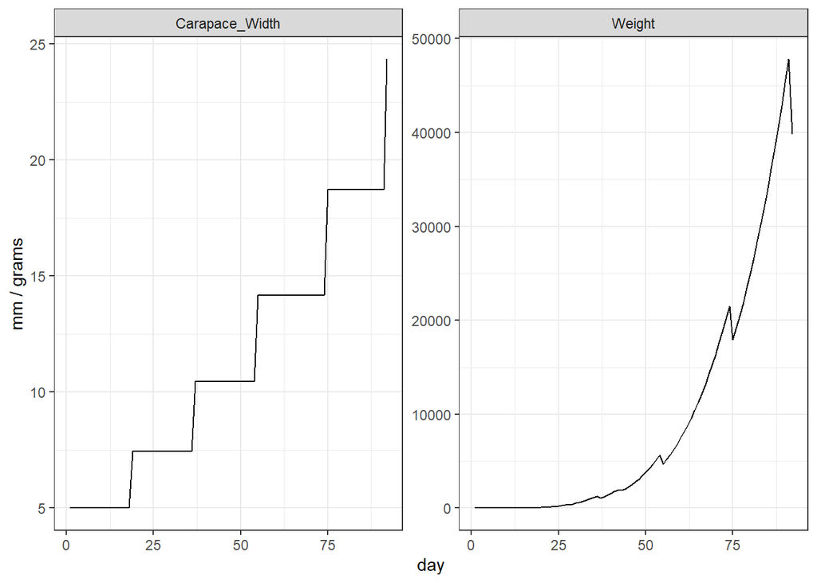

```r
plot.sim(sim.out =oa1.hiOlowE.sim,nd=nd)
```

final weight:

```r
oa1.hiOlowE.sim$W[nd]
```

```
## [1] 47800.93
```

### compare across OA exposures

With the highest energy density possible, a crab with high OA exposure will have what weight compared to a crab with low OA exposure? *a 33% decline in weight from low to high exposure*

```r
w.lo <- oa1.lowOhiE.sim$W[nd]
w.hi <- oa1.hiOhiE.sim$W[nd]

w.hi/w.lo
```

```
## [1] 0.6643788
```

```r
(w.hi - w.lo)/w.lo * 100
```

```
## [1] -33.56212
```

With the lowest energy density possible, a crab with high OA exposure will have what weight compared to a crab with low OA exposure? *equal (no change)*

```r
w.lo <- oa1.lowOlowE.sim$W[nd]
w.hi <- oa1.hiOlowE.sim$W[nd]


w.hi/w.lo
```

```
## [1] 1
```

```r
(w.hi - w.lo)/w.lo * 100
```

```
## [1] 0
```

# 3b. Simulate Growth: multiple prey items

randomly sample a set of 6 numbers from a normal distribution, and normalize to add to “1”. do this 1000 x. These will be the diet proportions.